# Introduction - Illustrative example

Theophanis Tsandilas and Géry Casiez

We detail our analysis for the illustrative example presented in the Introduction.

We use data from a hypothetical experiment that evaluates the time performance of three user interface techniques (*A*, *B*, and *C*) that help users complete image editing tasks of four different difficulty levels: *Level1*, *Level2*, *Level3*, and *Level4*.

The experiment follows a fully balanced repeated-measures factorial design, where each participant ($N = 12$) performs 12 tasks in a unique order. The researchers measure the time that it takes participants to complete each task, but participants also evaluate the perceived efficiency, using an ordinal scale with five levels.

### Preliminary

Let us first import all required libraries.

```r
library(lmerTest) # Lmer functions
library(ARTool) # ARTool library
library(effectsize) # To estimate effect sizes
```

```r
# Additional libraries for plotting and reporting
library(kableExtra)
library(gridExtra)
library(ggplot2)
library(tidyverse)
```

### Reading the dataset

We read our dataset and fix the type of the factors:

```r
df <- read.csv("example-data.csv", sep=",", header=TRUE, strip.white=TRUE)

df$Participant <- factor(df$Participant)
df$Difficulty <- factor(df$Difficulty, ordered = TRUE) # We can consider it as ordinal
df$Technique <- factor(df$Technique)

df$Perceived_Efficiency <- ordered(df$Perceived_Efficiency, levels = c("inefficient", "somewhat inefficient", "neutral", "somewhat efficient", "efficient"))
```

We present our dataset with a table:

```r
kbl(df, booktabs = TRUE) %>% kable_styling(font_size=14) %>% kable_paper(position = "center") %>% scroll_box(height = "170px")
```

| Participant | Difficulty | Technique | Time | Perceived_Efficiency |
| --- | --- | --- | --- | --- |
| P01 | Level1 | A | 0.20 | efficient |
| P01 | Level1 | B | 0.17 | somewhat efficient |
| P01 | Level1 | C | 0.14 | neutral |
| P01 | Level2 | A | 0.45 | efficient |
| P01 | Level2 | B | 0.50 | efficient |
| P01 | Level2 | C | 0.27 | neutral |
| P01 | Level3 | A | 0.64 | efficient |
| P01 | Level3 | B | 0.63 | efficient |
| P01 | Level3 | C | 0.83 | somewhat efficient |
| P01 | Level4 | A | 0.75 | efficient |
| P01 | Level4 | B | 1.35 | neutral |
| P01 | Level4 | C | 1.25 | somewhat efficient |
| P02 | Level1 | A | 0.71 | efficient |
| P02 | Level1 | B | 0.47 | efficient |
| P02 | Level1 | C | 0.59 | efficient |
| P02 | Level2 | A | 1.82 | efficient |
| P02 | Level2 | B | 0.87 | efficient |
| P02 | Level2 | C | 1.29 | efficient |
| P02 | Level3 | A | 1.35 | efficient |
| P02 | Level3 | B | 4.44 | efficient |
| P02 | Level3 | C | 1.92 | efficient |
| P02 | Level4 | A | 3.22 | efficient |
| P02 | Level4 | B | 9.62 | efficient |
| P02 | Level4 | C | 5.33 | efficient |
| P03 | Level1 | A | 0.55 | efficient |
| P03 | Level1 | B | 0.21 | efficient |
| P03 | Level1 | C | 0.43 | efficient |
| P03 | Level2 | A | 0.88 | efficient |
| P03 | Level2 | B | 1.07 | efficient |
| P03 | Level2 | C | 1.36 | efficient |

[output cut: 114 more lines]

### Plotting the data

We then plot our data to observe the main trends.

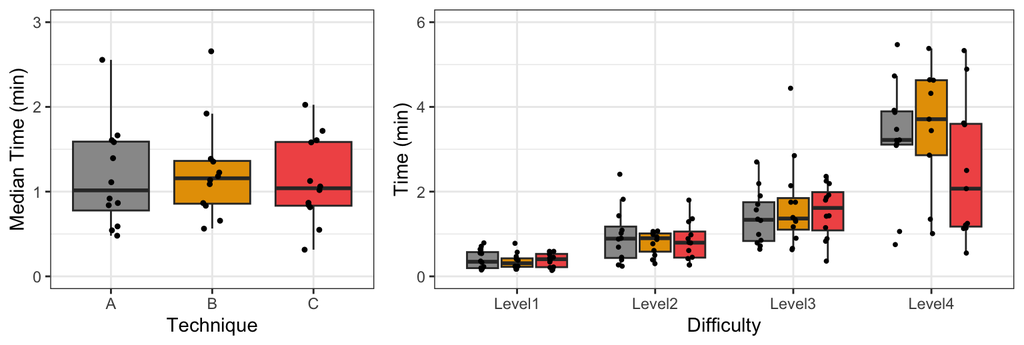

```r
cbPalette <- c("#999999", "#E69F00", "#F15854")

# Plots for the time measure
p1 <- (df %>%  group_by(Participant,Technique) %>%
summarise(Time = median(Time), .groups="drop") %>%
        ggplot(aes(x = Technique, y = Time, fill = Technique)) +
        geom_boxplot(outlier.shape = NA) +
        ylab("Median Time (min)") +
        ylim(0, 3) +
        geom_jitter(shape=20, position=position_jitter(0.1)) +
        theme_bw() + theme(legend.position = "none")) + scale_fill_manual(values=cbPalette)


p2 <- (df %>%  group_by(Participant,Difficulty,Technique) %>%
           summarise(Time = median(Time), .groups="drop") %>%
        ggplot(aes(x = Difficulty, y = Time, fill = Technique)) +
        geom_boxplot(outlier.shape = NA) +
        ylab("Time (min)") +
        ylim(0, 6) +
        geom_point(size = 0.7, position=position_jitterdodge(0.1)) +
        theme_bw() + theme(legend.position = "none")) +
        scale_fill_manual(values=cbPalette)

grid.arrange(p1, p2, nrow = 1, widths = c(1.5, 2.5))
```

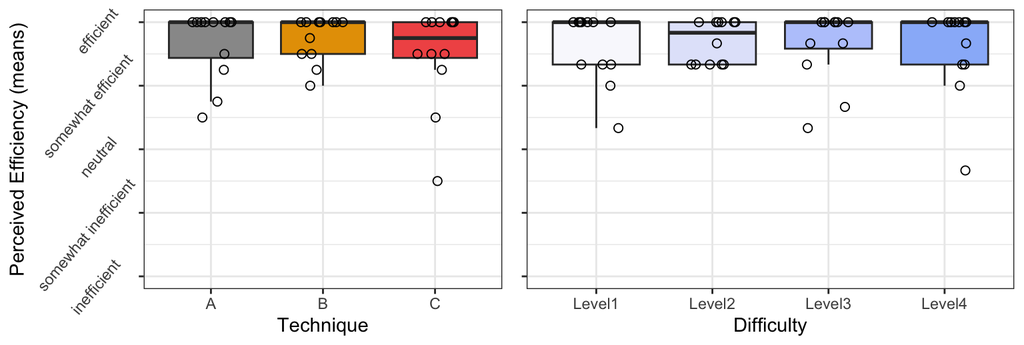

```r
# Plots for the perceived efficiency measure
dd1 <- df %>%  group_by(Participant,Technique) %>% summarise(Perceived_Efficiency = mean(as.integer(Perceived_Efficiency)), .groups="drop")

p3 <- (dd1 %>%
        ggplot(aes(x = Technique, y = Perceived_Efficiency, fill = Technique)) +
        geom_boxplot(outlier.shape = NA) +
        ylab("Perceived Efficiency (means)") +
        scale_y_continuous(breaks = 1:5, limits = c(1,5), labels=levels(df$Perceived_Efficiency)) +
        geom_jitter(shape=1, position=position_jitter(0.2,0), size = 2) +
        theme_bw() + theme(legend.position = "none")) + scale_fill_manual(values=cbPalette) +
        theme(axis.text.y=element_text(angle=50, hjust=0.7))

dd2 <- df %>%  group_by(Participant,Difficulty) %>% summarise(Perceived_Efficiency = mean(as.integer(Perceived_Efficiency)), .groups="drop")
diffPalette <- c("#f9f9fd", "#e2e6fa", "#bacafb", "#99b9f9")
p4 <- (dd2 %>%
        ggplot(aes(x = Difficulty, y = Perceived_Efficiency, fill = Difficulty)) +
        geom_boxplot(outlier.shape = NA) + ylim(1,5)+
        geom_jitter(shape=1, position=position_jitter(0.2,0), size = 2) +
        theme_bw() + theme(legend.position = "none")) + scale_fill_manual(values=diffPalette) +
        theme(axis.title.y=element_blank(), axis.text.y=element_blank())

grid.arrange(p3, p4, nrow = 1, widths = c(3, 3))
```

### Statistical analysis of time performance

For task-completion times, we conduct an analysis with five different methods: PAR, LOG, RNK, ART, and INT.

```r
# Implementation of the Inverse Normal Transform
int = function(x){
   qnorm((rank(x) - 0.5)/length(x))
}

mpar <- aov(Time ~ Difficulty*Technique + Error(Participant), data=df) # Parametric - no transformation
mlog <- aov(log(Time) ~ Difficulty*Technique + Error(Participant), data=df) # Parametric - Log-transformation
mart <- art(Time ~ Difficulty*Technique + Error(Participant), data=df) # ARTool
mrnk <- aov(rank(Time) ~ Difficulty*Technique + Error(Participant), data=df) # Rank transformation
mint <- aov(int(Time) ~ Difficulty*Technique + Error(Participant), data=df) # Inverse Transform transformation
```

#### Main and interaction effects

We report the results of our analysis.

```r
# Function for printing the results for each method
printAnalysis <- function(num, method, model) {
  cat(num, ". Analysis using ", method, "\n\n", sep="")

  if(method == "ART") print(anova(model))
  else print(summary(model))
  print(eta_squared(model))
  print(cohens_f(model))
}

printAnalysis(1, "Logarithmic Transformation", mlog)
```

```
## 1. Analysis using Logarithmic Transformation
##
##
## Error: Participant
##           Df Sum Sq Mean Sq F value Pr(>F)
## Residuals 11  28.65   2.604
##
## Error: Within
##                       Df Sum Sq Mean Sq F value Pr(>F)
## Difficulty             3  93.18  31.059 200.940 <2e-16 ***
## Technique              2   0.54   0.272   1.759  0.177
## Difficulty:Technique   6   1.68   0.279   1.808  0.103
## Residuals            121  18.70   0.155
## ---
## Signif. codes:  0 '***' 0.001 '**' 0.01 '*' 0.05 '.' 0.1 ' ' 1
## # Effect Size for ANOVA (Type I)
##
## Group  |            Parameter | Eta2 (partial) |       95% CI
## -------------------------------------------------------------
## Within |           Difficulty |           0.83 | [0.79, 1.00]
## Within |            Technique |           0.03 | [0.00, 1.00]
## Within | Difficulty:Technique |           0.08 | [0.00, 1.00]
##
## - One-sided CIs: upper bound fixed at [1.00].# Effect Size for ANOVA (Type I)
##
## Group  |            Parameter | Cohen's f (partial) |      95% CI
## -----------------------------------------------------------------
## Within |           Difficulty |                2.23 | [1.95, Inf]
## Within |            Technique |                0.17 | [0.00, Inf]
## Within | Difficulty:Technique |                0.30 | [0.00, Inf]
##
## - One-sided CIs: upper bound fixed at [Inf].
```

```r
printAnalysis(2, "ART", mart)
```

```
## 2. Analysis using ART
##
## Analysis of Variance of Aligned Rank Transformed Data
##
## Table Type: Repeated Measures Analysis of Variance Table (Type I)
## Model: Repeated Measures (aov)
## Response: art(Time)
##
##                        Error Df Df.res  F value     Pr(>F)
## 1 Difficulty           Withn  3    121 166.4298 < 2.22e-16 ***
## 2 Technique            Withn  2    121   7.8591 0.00061807 ***
## 3 Difficulty:Technique Withn  6    121   3.8015 0.00166465  **
## ---
## Signif. codes:   0 '***' 0.001 '**' 0.01 '*' 0.05 '.' 0.1 ' ' 1
## # Effect Size for ANOVA (Type I)
##
## Parameter | Eta2 (partial) |       95% CI
## -----------------------------------------
## 1         |           0.80 | [0.76, 1.00]
## 2         |           0.11 | [0.03, 1.00]
## 3         |           0.16 | [0.04, 1.00]
##
## - One-sided CIs: upper bound fixed at [1.00].# Effect Size for ANOVA (Type I)
##
## Parameter | Cohen's f (partial) |      95% CI
## ---------------------------------------------
## 1         |                2.03 | [1.76, Inf]
## 2         |                0.36 | [0.19, Inf]
## 3         |                0.43 | [0.21, Inf]
##
## - One-sided CIs: upper bound fixed at [Inf].
```

```r
printAnalysis(3, "Rank Transformation", mrnk)
```

```
## 3. Analysis using Rank Transformation
##
##
## Error: Participant
##           Df Sum Sq Mean Sq F value Pr(>F)
## Residuals 11  46672    4243
##
## Error: Within
##                       Df Sum Sq Mean Sq F value Pr(>F)
## Difficulty             3 165050   55017 194.337 <2e-16 ***
## Technique              2    547     273   0.966  0.384
## Difficulty:Technique   6   2275     379   1.340  0.245
## Residuals            121  34255     283
## ---
## Signif. codes:  0 '***' 0.001 '**' 0.01 '*' 0.05 '.' 0.1 ' ' 1
## # Effect Size for ANOVA (Type I)
##
## Group  |            Parameter | Eta2 (partial) |       95% CI
## -------------------------------------------------------------
## Within |           Difficulty |           0.83 | [0.79, 1.00]
## Within |            Technique |           0.02 | [0.00, 1.00]
## Within | Difficulty:Technique |           0.06 | [0.00, 1.00]
##
## - One-sided CIs: upper bound fixed at [1.00].# Effect Size for ANOVA (Type I)
##
## Group  |            Parameter | Cohen's f (partial) |      95% CI
## -----------------------------------------------------------------
## Within |           Difficulty |                2.20 | [1.91, Inf]
## Within |            Technique |                0.13 | [0.00, Inf]
## Within | Difficulty:Technique |                0.26 | [0.00, Inf]
##
## - One-sided CIs: upper bound fixed at [Inf].
```

```r
printAnalysis(4, "Inverse Normal Transformation", mint)
```

```
## 4. Analysis using Inverse Normal Transformation
##
##
## Error: Participant
##           Df Sum Sq Mean Sq F value Pr(>F)
## Residuals 11  28.62   2.602
##
## Error: Within
##                       Df Sum Sq Mean Sq F value Pr(>F)
## Difficulty             3  91.15  30.383 177.050 <2e-16 ***
## Technique              2   0.61   0.306   1.785  0.172
## Difficulty:Technique   6   1.43   0.238   1.387  0.225
## Residuals            121  20.76   0.172
## ---
## Signif. codes:  0 '***' 0.001 '**' 0.01 '*' 0.05 '.' 0.1 ' ' 1
## # Effect Size for ANOVA (Type I)
##
## Group  |            Parameter | Eta2 (partial) |       95% CI
## -------------------------------------------------------------
## Within |           Difficulty |           0.81 | [0.77, 1.00]
## Within |            Technique |           0.03 | [0.00, 1.00]
## Within | Difficulty:Technique |           0.06 | [0.00, 1.00]
##
## - One-sided CIs: upper bound fixed at [1.00].# Effect Size for ANOVA (Type I)
##
## Group  |            Parameter | Cohen's f (partial) |      95% CI
## -----------------------------------------------------------------
## Within |           Difficulty |                2.10 | [1.82, Inf]
## Within |            Technique |                0.17 | [0.00, Inf]
## Within | Difficulty:Technique |                0.26 | [0.00, Inf]
##
## - One-sided CIs: upper bound fixed at [Inf].
```

```r
printAnalysis(5, "No Transformation", mpar)
```

```
## 5. Analysis using No Transformation
##
##
## Error: Participant
##           Df Sum Sq Mean Sq F value Pr(>F)
## Residuals 11  59.66   5.423
##
## Error: Within
##                       Df Sum Sq Mean Sq F value Pr(>F)
## Difficulty             3 233.73   77.91  70.587 <2e-16 ***
## Technique              2   5.08    2.54   2.300 0.1046
## Difficulty:Technique   6  14.02    2.34   2.117 0.0561 .
## Residuals            121 133.55    1.10
## ---
## Signif. codes:  0 '***' 0.001 '**' 0.01 '*' 0.05 '.' 0.1 ' ' 1
## # Effect Size for ANOVA (Type I)
##
## Group  |            Parameter | Eta2 (partial) |       95% CI
## -------------------------------------------------------------
## Within |           Difficulty |           0.64 | [0.55, 1.00]
## Within |            Technique |           0.04 | [0.00, 1.00]
## Within | Difficulty:Technique |           0.10 | [0.00, 1.00]
##
## - One-sided CIs: upper bound fixed at [1.00].# Effect Size for ANOVA (Type I)
##
## Group  |            Parameter | Cohen's f (partial) |      95% CI
## -----------------------------------------------------------------
## Within |           Difficulty |                1.32 | [1.11, Inf]
## Within |            Technique |                0.19 | [0.00, Inf]
## Within | Difficulty:Technique |                0.32 | [0.00, Inf]
##
## - One-sided CIs: upper bound fixed at [Inf].
```

We observe that only ART shows statistical evidence for a main effect of Technique, as well as an interaction effect.

### Statistical analysis of perceived efficiency

We conduct an analysis with PAR, RNK, ART, and INT.

```r
df$Perceived_Efficiency <- as.integer(df$Perceived_Efficiency)

mpar <- aov(Perceived_Efficiency ~ Difficulty*Technique + Error(Participant), data=df) # Parametric - no transformation
mart <- art(Perceived_Efficiency ~ Difficulty*Technique + Error(Participant), data=df) # ARTool
mrnk <- aov(rank(Perceived_Efficiency) ~ Difficulty*Technique + Error(Participant), data=df) # Rank transformation
mint <- aov(int(Perceived_Efficiency) ~ Difficulty*Technique + Error(Participant), data=df) # Inverse Transform transformation
```

We report the results of our analysis.

```r
printAnalysis(2, "ART", mart)
```

```
## 2. Analysis using ART
##
## Analysis of Variance of Aligned Rank Transformed Data
##
## Table Type: Repeated Measures Analysis of Variance Table (Type I)
## Model: Repeated Measures (aov)
## Response: art(Perceived_Efficiency)
##
##                        Error Df Df.res F value     Pr(>F)
## 1 Difficulty           Withn  3    121  5.6803 0.00112985  **
## 2 Technique            Withn  2    121  9.3750 0.00016396 ***
## 3 Difficulty:Technique Withn  6    121  1.8110 0.10242471
## ---
## Signif. codes:   0 '***' 0.001 '**' 0.01 '*' 0.05 '.' 0.1 ' ' 1
## # Effect Size for ANOVA (Type I)
##
## Parameter | Eta2 (partial) |       95% CI
## -----------------------------------------
## 1         |           0.12 | [0.03, 1.00]
## 2         |           0.13 | [0.05, 1.00]
## 3         |           0.08 | [0.00, 1.00]
##
## - One-sided CIs: upper bound fixed at [1.00].# Effect Size for ANOVA (Type I)
##
## Parameter | Cohen's f (partial) |      95% CI
## ---------------------------------------------
## 1         |                0.38 | [0.19, Inf]
## 2         |                0.39 | [0.22, Inf]
## 3         |                0.30 | [0.00, Inf]
##
## - One-sided CIs: upper bound fixed at [Inf].
```

```r
printAnalysis(3, "Rank Transformation", mrnk)
```

```
## 3. Analysis using Rank Transformation
##
##
## Error: Participant
##           Df Sum Sq Mean Sq F value Pr(>F)
## Residuals 11  36881    3353
##
## Error: Within
##                       Df Sum Sq Mean Sq F value Pr(>F)
## Difficulty             3    477   159.1   0.256  0.857
## Technique              2   1437   718.4   1.155  0.319
## Difficulty:Technique   6   4331   721.8   1.160  0.332
## Residuals            121  75289   622.2
## # Effect Size for ANOVA (Type I)
##
## Group  |            Parameter | Eta2 (partial) |       95% CI
## -------------------------------------------------------------
## Within |           Difficulty |       6.30e-03 | [0.00, 1.00]
## Within |            Technique |           0.02 | [0.00, 1.00]
## Within | Difficulty:Technique |           0.05 | [0.00, 1.00]
##
## - One-sided CIs: upper bound fixed at [1.00].# Effect Size for ANOVA (Type I)
##
## Group  |            Parameter | Cohen's f (partial) |      95% CI
## -----------------------------------------------------------------
## Within |           Difficulty |                0.08 | [0.00, Inf]
## Within |            Technique |                0.14 | [0.00, Inf]
## Within | Difficulty:Technique |                0.24 | [0.00, Inf]
##
## - One-sided CIs: upper bound fixed at [Inf].
```

```r
printAnalysis(4, "Inverse Normal Transformation", mint)
```

```
## 4. Analysis using Inverse Normal Transformation
##
##
## Error: Participant
##           Df Sum Sq Mean Sq F value Pr(>F)
## Residuals 11  20.32   1.848
##
## Error: Within
##                       Df Sum Sq Mean Sq F value Pr(>F)
## Difficulty             3   0.22  0.0741   0.218  0.884
## Technique              2   1.02  0.5086   1.497  0.228
## Difficulty:Technique   6   2.34  0.3898   1.148  0.339
## Residuals            121  41.10  0.3397
## # Effect Size for ANOVA (Type I)
##
## Group  |            Parameter | Eta2 (partial) |       95% CI
## -------------------------------------------------------------
## Within |           Difficulty |       5.38e-03 | [0.00, 1.00]
## Within |            Technique |           0.02 | [0.00, 1.00]
## Within | Difficulty:Technique |           0.05 | [0.00, 1.00]
##
## - One-sided CIs: upper bound fixed at [1.00].# Effect Size for ANOVA (Type I)
##
## Group  |            Parameter | Cohen's f (partial) |      95% CI
## -----------------------------------------------------------------
## Within |           Difficulty |                0.07 | [0.00, Inf]
## Within |            Technique |                0.16 | [0.00, Inf]
## Within | Difficulty:Technique |                0.24 | [0.00, Inf]
##
## - One-sided CIs: upper bound fixed at [Inf].
```

```r
printAnalysis(5, "No Transformation", mpar)
```

```
## 5. Analysis using No Transformation
##
##
## Error: Participant
##           Df Sum Sq Mean Sq F value Pr(>F)
## Residuals 11  28.24   2.568
##
## Error: Within
##                       Df Sum Sq Mean Sq F value Pr(>F)
## Difficulty             3   0.24  0.0810   0.151  0.929
## Technique              2   1.85  0.9236   1.719  0.184
## Difficulty:Technique   6   4.15  0.6921   1.288  0.268
## Residuals            121  65.01  0.5372
## # Effect Size for ANOVA (Type I)
##
## Group  |            Parameter | Eta2 (partial) |       95% CI
## -------------------------------------------------------------
## Within |           Difficulty |       3.72e-03 | [0.00, 1.00]
## Within |            Technique |           0.03 | [0.00, 1.00]
## Within | Difficulty:Technique |           0.06 | [0.00, 1.00]
##
## - One-sided CIs: upper bound fixed at [1.00].# Effect Size for ANOVA (Type I)
##
## Group  |            Parameter | Cohen's f (partial) |      95% CI
## -----------------------------------------------------------------
## Within |           Difficulty |                0.06 | [0.00, Inf]
## Within |            Technique |                0.17 | [0.00, Inf]
## Within | Difficulty:Technique |                0.25 | [0.00, Inf]
##
## - One-sided CIs: upper bound fixed at [Inf].
```

ART is the only method to detect an main effect for both Difficulty ($p=.0011$, partial $\eta^2 = .12$, $95\%$ CI $[.03, 1.0]$) and Technique ($p=.00016$, partial $\eta^2 = .13$, $95\%$ CI $[.05, 1.0]$). Its *p-*values are substantially lower than the *p-*values of the other methods, and its effect size estimates are surprisingly large.